# Avaliando a diferença entre os anos de hanseníase no Brasil

Autor

Mikael Marin Coletto

Data de Publicação

12 de dezembro de 2024

# Introdução

A hanseníase é uma doença infecciosa causada pelo bacilo Mycobacterium leprae. Embora tenha sido controlada em muitas partes do mundo, ainda persiste em algumas regiões, especialmente em países em desenvolvimento como o Brasil, Índia e Indonésia. A Organização Mundial da Saúde (OMS) estabeleceu metas para eliminar a hanseníase como problema de saúde pública, definindo uma taxa de incidência anual inferior a 1 caso por 10.000 habitantes. No contexto brasileiro, onde a doença ainda apresenta uma considerável prevalência, os governos federais tem tentado implementar estratégias para aumentar a vigilância e consequentemente facilitar o tratamento, já que é uma doença de tratamento relativamente simples se diagnosticada em estágios iniciais.

Neste relatório, utilizaremos testes estatísticos não paramétricos para avaliar as diferenças nas prevalências de hanseníase no Brasil ao longo dos anos, comparando diferentes estados. Além disso, analisaremos a diferença no número de casos entre dois estados específicos para determinar a eficácia das políticas públicas de prevenção da doença.

# Métodos

Para esta análise, coletamos dados oficiais de casos de notificação de hanseníase nos estados brasileiros ao longo de vários anos. Os dados foram obtidos do Ministério da Saúde do Brasil, usando o tabnet e baixando a base do Sistema de informação de Agravos de Notificação (SINAN) e abrangem um período de 23 anos (2001-2023).

Inicialmente faremos uma análise descritiva da base de dados.

Primeiramente, realizamos um teste não paramétrico para duas amostras independentes para comparar a diferença na incidência de hanseníase entre estados ao longo dos anos. Especificamente, utilizamos o teste de Mann-Whitney U, que é adequado para comparar medias de duas amostras independentes quando as suposições dos testes paramétricos não são satisfeitas.

Além disso, selecionamos dois estados com diferentes abordagens em políticas públicas de tratamento da hanseníase e compararamos o número de casos nestes estados ao longo do mesmo período de tempo. Novamente, aplicamos o teste de Mann-Whitney U para determinar se há uma diferença significativa nos números de casos entre esses dois estados.

# Resultados

## Avaliando banco de dados

A primeira etapa desenvolvida foi uma análise exploratória dos dados de hanseníase obtidos através do sinan, para isso, carregamos os dados e observamos a completude dos dados no quesito data de diagnóstico e o ID do agravo (CID).

**Código**

```r
sinan_hans <- data.table::fread(
  paste0("dados/sinan_hansbr_2001_2023.csv")) |>
  dplyr::rename(CID = ID_AGRAVO, DATA = DT_DIAG) |>
  dplyr::mutate(
    UF = substr(ID_MUNICIP, 1, 2),
    data_format = lubridate::ymd(DATA),
    # Extraindo mes e ano da data
    ano = substr(DATA, 1, 4),
    mes = substr(DATA, 5, 6),
    ano_mes = paste0(ano, "-", mes))

## Verificando CID, se temos apenas o de Hanseníase
cid_distinct <- dplyr::distinct(sinan_hans, CID) |> dplyr::pull()

# Observando preenchimento de CID e datas
n_inv_cid_data <- sinan_hans |>
  dplyr::filter(is.na(CID) | is.na(DATA)) |>
  dplyr::count() |>
  dplyr::pull()
```

Pelo código desenvolvido, foi observado que o único CID disponível nesta base de dados é o de Hanseníase A309. Além disso, não temos nenhum caso sem CID ou sem data de diagnóstico preenchida (a contagem retornou 0). Porém, temos casos de diagnóstico em datas muito mais antigas do que a análise propôs, portanto os casos anteriores à 2001 serão removidos da base de dados logo adiante, o que pode ser um erro de preenchimento ou um caso de diagnóstico tardio.

## Análise exploratória

### Analisando o número de casos por ano/mês no Brasil

**Código**

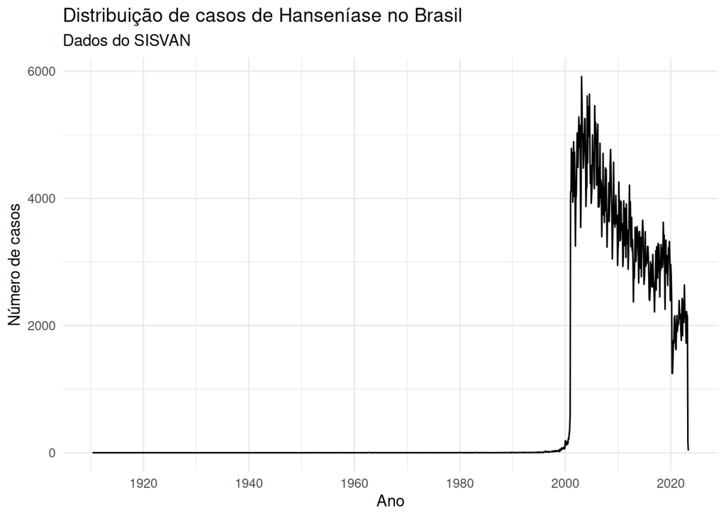

```r
## Fazendo contagens por ano/mês
sinan_hans_2001_2023_anomes <- sinan_hans |>
  dplyr::group_by(ano_mes) |>
  dplyr::mutate(n = n()) |>
  dplyr::distinct(ano_mes, .keep_all = T)

sinan_hans_2001_2023_anomes <- sinan_hans_2001_2023_anomes |>
  dplyr::mutate(ano_mes_graf = lubridate::ymd(paste0(ano_mes, "-01")))

## Criando gráfico da distribuição de casos
sinan_hans_2001_2023_anomes |>
  ggplot2::ggplot(ggplot2::aes(x = ano_mes_graf, y = n)) +
  ggplot2::geom_line() +
  ggplot2::labs(
    title = "Distribuição de casos de Hanseníase no Brasil",
    subtitle = "Dados do SISVAN",
    x = "Ano",
    y = "Número de casos") +
  ggplot2::theme_minimal()
```

**Código**

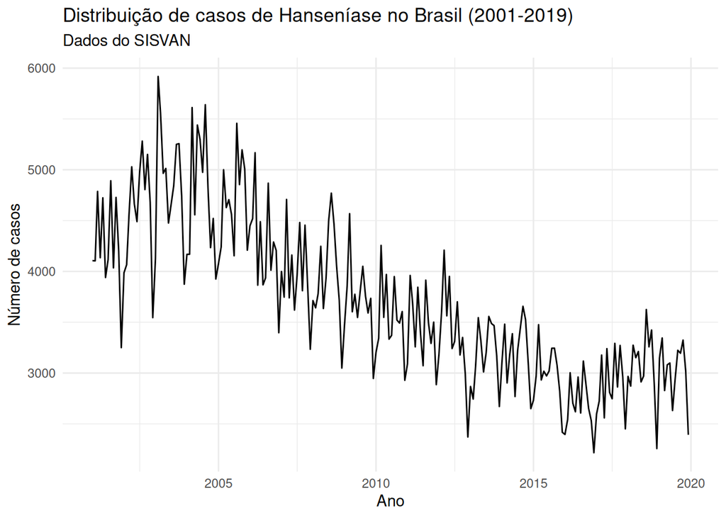

```r
## Removendo anos anteriores e posteriores a período determinado (dados incompletos)
sinan_hans_2001_2023_anomes_brasil <- sinan_hans_2001_2023_anomes |>
  dplyr::filter(ano >= "2001", ano <= "2019")

sinan_hans_2001_2023_anomes_brasil |>
  ggplot2::ggplot(ggplot2::aes(x = ano_mes_graf, y = n)) +
  ggplot2::geom_line() +
  ggplot2::labs(
    title = "Distribuição de casos de Hanseníase no Brasil (2001-2019)",
    subtitle = "Dados do SISVAN",
    x = "Ano",
    y = "Número de casos") +
  ggplot2::theme_minimal()
```

### Analisando normalidade dos dados

**Código**

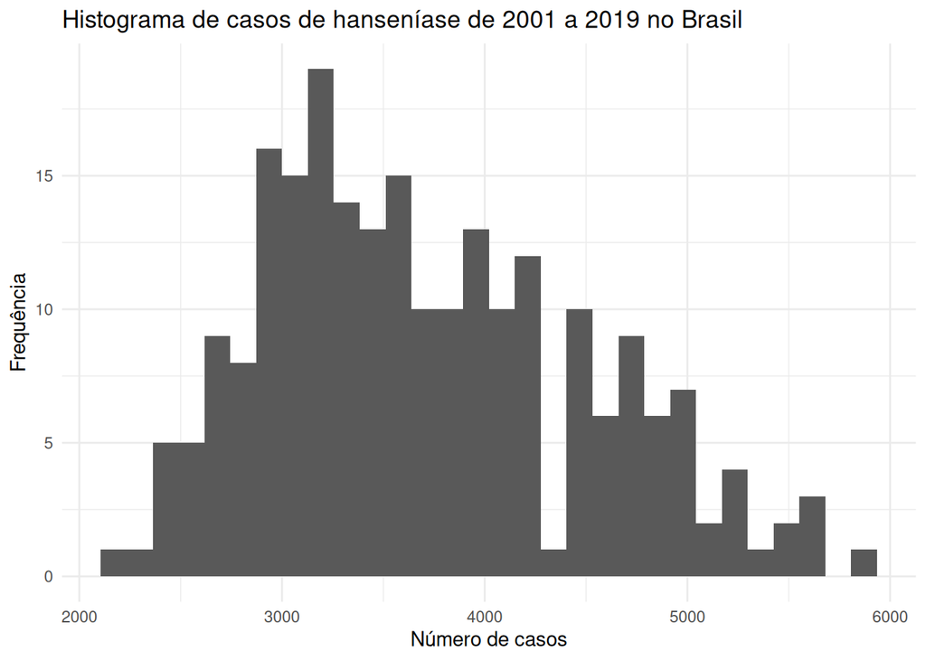

```r
## Histograma dos dados
sinan_hans_2001_2023_anomes_brasil |>
  ggplot2::ggplot(ggplot2::aes(x = n)) +
  ggplot2::geom_histogram(bins = 30) +
  ggplot2::labs(
    title = "Histograma de casos de hanseníase de 2001 a 2019 no Brasil",
    x = "Número de casos",
    y = "Frequência") +
  ggplot2::theme_minimal()
```

**Código**

```r
## Teste de Shapiro-Wilk
shapiro.test(sinan_hans_2001_2023_anomes_brasil$n)
```

```
    Shapiro-Wilk normality test

data:  sinan_hans_2001_2023_anomes_brasil$n
W = 0.97042, p-value = 0.0001063
```

**Código**

```r
ks.test(sinan_hans_2001_2023_anomes_brasil$n, "pnorm", mean(sinan_hans_2001_2023_anomes_brasil$n), sd(sinan_hans_2001_2023_anomes_brasil$n))
```

```
    Asymptotic one-sample Kolmogorov-Smirnov test

data:  sinan_hans_2001_2023_anomes_brasil$n
D = 0.080053, p-value = 0.1076
alternative hypothesis: two-sided
```

### Analisando dados por UF

Agora iremos observar os dados de algumas UFs, para isso, iremos agrupar os dados por UF e ano/mês e observar a distribuição de casos de hanseníase para Bahia e Rio Grande do Sul.

**Código**

[figure not shown]

```r
## Lendo dados de UF
uf_nome_cod <- data.table::fread(
  paste0("dados/cod_ibge_mun_capitais.csv")) |>
  dplyr::mutate(cod_ibge = substr(cod_ibge, 1, 2)) |>
  dplyr::select(cod_ibge, nome_uf)

## Agrupando por UF e removendo anos antes de 2001 e pós 2023
sinan_hans_uf_2001_2019 <- sinan_hans |>
  dplyr::filter(ano >= "2001", ano <= "2019") |>
  dplyr::group_by(UF, ano_mes) |>
  dplyr::summarise(n = n()) |>
  dplyr::ungroup()

sinan_hans_2001_2019_anomes_ba_rs <- sinan_hans |>
  dplyr::group_by(ano_mes, UF) |>
  dplyr::mutate(n = n()) |>
  dplyr::distinct(ano_mes, .keep_all = T) |>
  dplyr::filter(UF %in% c("29", "43")) |>
  dplyr::filter(ano >= "2001", ano <= "2019") |>
  dplyr::mutate(ano_mes_graf = lubridate::ymd(paste0(ano_mes, "-01"))) |>
  dplyr::select(UF, ano_mes, ano_mes_graf, n) |>
  dplyr::inner_join(uf_nome_cod, by=dplyr::join_by(UF == cod_ibge)) |>
  dplyr::ungroup()

## Apresentando gráfico do número de casos por ano/mês nos estados do Sul
sinan_hans_2001_2019_anomes_ba_rs |>
  ggplot2::ggplot(ggplot2::aes(x = ano_mes_graf, y = n, color = nome_uf)) +
  ggplot2::geom_line() +
  ggplot2::labs(
    title = "Distribuição de casos de Hanseníase no Sul do Brasil",
    subtitle = "Dados do SISVAN",
    x = "Ano",
    y = "Número de casos") +
  ggplot2::theme_minimal()
```

**Código**

[figure not shown]

```r
## Unindo com dados do SINAN
sinan_hans_uf_2001_2019 <- dplyr::inner_join(sinan_hans_uf_2001_2019, uf_nome_cod,
                                             by=dplyr::join_by(UF == cod_ibge))


## Criando histograma dos dados da Bahia
sinan_hans_uf_2001_2019_ba <- sinan_hans_uf_2001_2019 |>
  dplyr::filter(nome_uf == "Bahia")

sinan_hans_uf_2001_2019_ba |>
  ggplot2::ggplot(ggplot2::aes(x = n)) +
  ggplot2::geom_histogram(bins = 30) +
  ggplot2::labs(
    title = "Histograma de casos de hanseníase de 2001 a 2019 no RS",
    x = "Número de casos",
    y = "Frequência") +
  ggplot2::theme_minimal()
```

**Código**

```r
## Rodando o teste de normalidade para a Bahia
shapiro.test(sinan_hans_uf_2001_2019_ba |> dplyr::pull(n))
```

```
    Shapiro-Wilk normality test

data:  dplyr::pull(sinan_hans_uf_2001_2019_ba, n)
W = 0.94619, p-value = 0.0000001798
```

**Código**

```r
ks.test(sinan_hans_uf_2001_2019_ba$n, "pnorm", mean(sinan_hans_uf_2001_2019_ba$n), sd(sinan_hans_uf_2001_2019_ba$n))
```

```
    Asymptotic one-sample Kolmogorov-Smirnov test

data:  sinan_hans_uf_2001_2019_ba$n
D = 0.095217, p-value = 0.03203
alternative hypothesis: two-sided
```

**Código**

```r
nortest::ad.test(sinan_hans_uf_2001_2019_ba$n)
```

```
    Anderson-Darling normality test

data:  sinan_hans_uf_2001_2019_ba$n
A = 2.6535, p-value = 0.000001042
```

**Código**

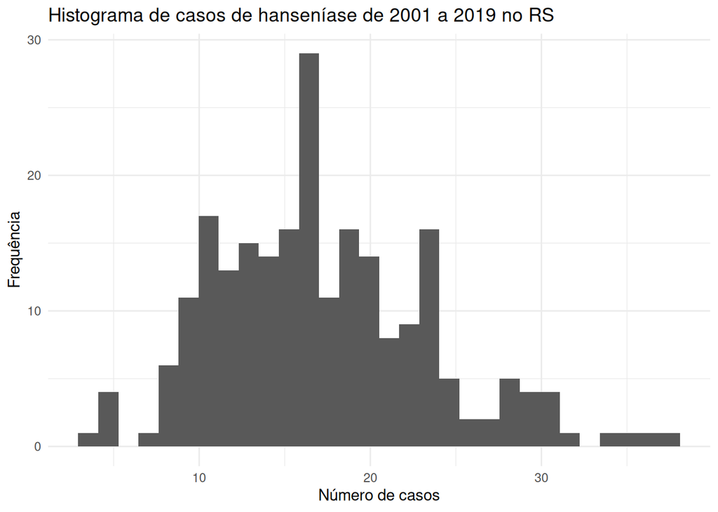

```r
## Criando histograma dos dados para o Rio Grande do Sul
sinan_hans_uf_2001_2019_rs <- sinan_hans_uf_2001_2019 |>
  dplyr::filter(nome_uf == "Rio Grande do Sul")

sinan_hans_uf_2001_2019_rs |>
  ggplot2::ggplot(ggplot2::aes(x = n)) +
  ggplot2::geom_histogram(bins = 30) +
  ggplot2::labs(
    title = "Histograma de casos de hanseníase de 2001 a 2019 no RS",
    x = "Número de casos",
    y = "Frequência") +
  ggplot2::theme_minimal()
```

**Código**

```r
## Rodando o teste de normalidade para o RS
shapiro.test(sinan_hans_uf_2001_2019_rs |> dplyr::pull(n))
```

```
    Shapiro-Wilk normality test

data:  dplyr::pull(sinan_hans_uf_2001_2019_rs, n)
W = 0.97645, p-value = 0.000748
```

**Código**

```r
ks.test(sinan_hans_uf_2001_2019_rs$n, "pnorm", mean(sinan_hans_uf_2001_2019_rs$n), sd(sinan_hans_uf_2001_2019_rs$n))
```

```
    Asymptotic one-sample Kolmogorov-Smirnov test

data:  sinan_hans_uf_2001_2019_rs$n
D = 0.079931, p-value = 0.1086
alternative hypothesis: two-sided
```

**Código**

```r
nortest::ad.test(sinan_hans_uf_2001_2019_rs$n)
```

```
    Anderson-Darling normality test

data:  sinan_hans_uf_2001_2019_rs$n
A = 1.3067, p-value = 0.002114
```

**Código**

```r
# ks.test(ba_hans_2001_2019, "pnorm", mean(ba_hans_2001_2019), sd(ba_hans_2001_2019))
# nortest::ad.test(ba_hans_2001_2019)
```

## Comparando a prevalência de hanseníase entre estados

Agora vamos comparar a prevalência de hanseníase entre os estados brasileiros ao longo dos anos. Para isso, utilizaremos o teste de Mann-Whitney U para comparar as médias de duas amostras independentes. Vamos separar os dados por UF (Bahia e Rio Grande do Sul) e iremos comparar os valores de prevalência de hanseníase entre esses dois estados.

**Código**

```r
## Organizando os dados
sinan_hans_2001_2019_anomes_ba_rs <- sinan_hans |>
  dplyr::group_by(ano_mes, UF) |>
  dplyr::mutate(n = n()) |>
  dplyr::distinct(ano_mes, .keep_all = T) |>
  dplyr::filter(UF %in% c("29", "43")) |>
  dplyr::filter(ano >= "2001", ano <= "2019") |>
  dplyr::mutate(ano_mes_graf = lubridate::ymd(paste0(ano_mes, "-01"))) |>
  dplyr::select(UF, ano_mes, ano_mes_graf, n) |>
  dplyr::inner_join(uf_nome_cod, by=dplyr::join_by(UF == cod_ibge)) |>
  dplyr::ungroup()

## Selecionando os anos para comparação

## Separando por coluna para comparação
sinan_hans_2001_2019_anomes_ba_rs_matrix <- sinan_hans_2001_2019_anomes_ba_rs |>
  dplyr::select(nome_uf, ano_mes, n) |>
  tidyr::pivot_wider(names_from = nome_uf, values_from = n) |>
  dplyr::select(-ano_mes)

## Rodando o teste U de Mann-Whitney para amostras independentes
wilcox.test(sinan_hans_2001_2019_anomes_ba_rs_matrix$Bahia,
            sinan_hans_2001_2019_anomes_ba_rs_matrix$`Rio Grande do Sul`,
            alternative = "two.sided", paired = FALSE)
```

```
    Wilcoxon rank sum test with continuity correction

data:  sinan_hans_2001_2019_anomes_ba_rs_matrix$Bahia and sinan_hans_2001_2019_anomes_ba_rs_matrix$`Rio Grande do Sul`
W = 51984, p-value < 0.00000000000000022
alternative hypothesis: true location shift is not equal to 0
```

O resultado do teste U de Mann-Whitney foi significativo (p-valor < 0.05), indicando que há uma diferença significativa na prevalência de hanseníase entre os estados da Bahia e do Rio Grande do Sul ao longo dos anos.

## Comparando o número de casos de hanseníase em diferentes estados da mesma região

Agora vamos comparar o número de casos de hanseníase em uma região específica no período selecionado, usaremos os estados do Sul, portanto Paraná, Rio Grande do Sul e Santa Catarina, para observarmos se a diferença de casos também está presente, ou se os indicadores socioeconômicos influenciam a prevalência encontrada. Utilizaremos como um delineamento em blocos, onde os blocos serão as UFs, e os grupos (ou “tratamentos”) serão os anos/meses observados.

**Código**

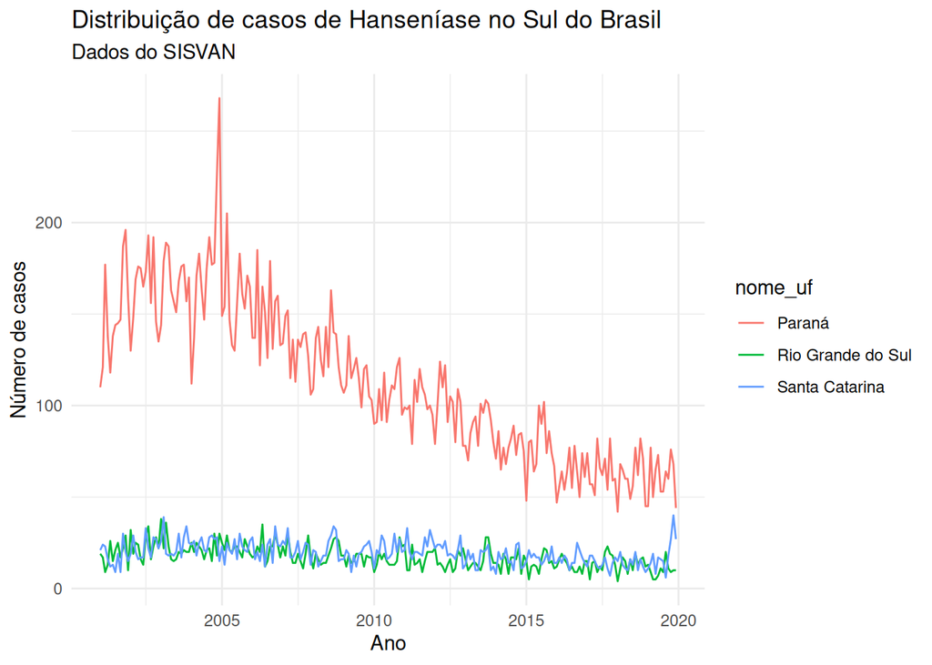

```r
## Organizando os dados
sinan_hans_2001_2019_anomes_sul <- sinan_hans |>
  dplyr::group_by(ano_mes, UF) |>
  dplyr::mutate(n = n()) |>
  dplyr::distinct(ano_mes, .keep_all = T) |>
  dplyr::filter(UF %in% c("41", "43", "42")) |>
  dplyr::filter(ano >= "2001", ano <= "2019") |>
  dplyr::mutate(ano_mes_graf = lubridate::ymd(paste0(ano_mes, "-01"))) |>
  dplyr::select(UF, ano_mes, ano_mes_graf, n) |>
  dplyr::inner_join(uf_nome_cod, by=dplyr::join_by(UF == cod_ibge)) |>
  dplyr::ungroup()

## Apresentando gráfico do número de casos por ano/mês nos estados do Sul
sinan_hans_2001_2019_anomes_sul |>
  ggplot2::ggplot(ggplot2::aes(x = ano_mes_graf, y = n, color = nome_uf)) +
  ggplot2::geom_line() +
  ggplot2::labs(
    title = "Distribuição de casos de Hanseníase no Sul do Brasil",
    subtitle = "Dados do SISVAN",
    x = "Ano",
    y = "Número de casos") +
  ggplot2::theme_minimal()
```

**Código**

```r
## Rodando o teste de Friedman
friedman.test(y = sinan_hans_2001_2019_anomes_sul$n,
              groups = sinan_hans_2001_2019_anomes_sul$ano_mes,
              blocks = sinan_hans_2001_2019_anomes_sul$nome_uf)
```

```
    Friedman rank sum test

data:  sinan_hans_2001_2019_anomes_sul$n, sinan_hans_2001_2019_anomes_sul$ano_mes and sinan_hans_2001_2019_anomes_sul$nome_uf
Friedman chi-squared = 434.15, df = 227, p-value = 0.000000000000003847
```

**Código**

```r
pgirmess::friedmanmc(y = sinan_hans_2001_2019_anomes_sul$n,
                     groups = sinan_hans_2001_2019_anomes_sul$nome_uf,
                     blocks = sinan_hans_2001_2019_anomes_sul$ano_mes)
```

```
Multiple comparisons between groups after Friedman test
alpha: 0.05
Comparisons
                                 obs.dif critical.dif stat.signif
Paraná-Rio Grande do Sul             373     51.12142        TRUE
Paraná-Santa Catarina                311     51.12142        TRUE
Rio Grande do Sul-Santa Catarina      62     51.12142        TRUE
                                                                                                     p.value
Paraná-Rio Grande do Sul         0.0000000000000000000000000000000000000000000000000000000000000000001524792
Paraná-Santa Catarina            0.0000000000000000000000000000000000000000000000285917361144504989689542733
Rio Grande do Sul-Santa Catarina 0.0221469573723492296757342501223320141434669494628906250000000000000000000
```

## Comparando o número de casos entre os primeiros anos de notificação e os últimos

Uma outra coisa que podemos observar no primeiro gráfico da distribuição dos dados no país é que a quantidade de casos de hanseníase vem diminuindo ao longo dos anos, porém gostaríamos de verificar se essa diminuição é significativa. Para termos uma amostra maior, utilizaremos como grupos os anos de 2001 para representar os anos iniciais e 2019 para representar os anos finais, e como blocos diferentes estados do país.

**Código**

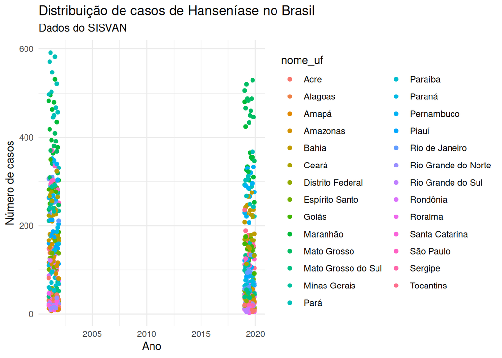

```r
## Organizando os dados
sinan_hans_2001_2019_anomes_inicio_fim <- sinan_hans |>
  dplyr::group_by(ano_mes, UF) |>
  dplyr::mutate(n = n()) |>
  dplyr::distinct(ano_mes, .keep_all = T) |>
  dplyr::filter(ano %in% c("2001", "2019")) |>
  dplyr::mutate(inicio_fim = ifelse(ano == "2001", "Inicio", "Fim")) |>
  dplyr::mutate(ano_mes_graf = lubridate::ymd(paste0(ano_mes, "-01"))) |>
  dplyr::select(UF, ano_mes, ano_mes_graf, n, inicio_fim) |>
  dplyr::inner_join(uf_nome_cod, by=dplyr::join_by(UF == cod_ibge)) |>
  dplyr::ungroup()

## Apresentando gráfico do número de casos por ano/mês nos anos iniciais e anos finais
sinan_hans_2001_2019_anomes_inicio_fim |>
  ggplot2::ggplot(ggplot2::aes(x = ano_mes_graf, y = n, color = nome_uf)) +
  ggplot2::geom_point() +
  # ggplot2::facet_wrap(~inicio_fim) +
  ggplot2::labs(
    title = "Distribuição de casos de Hanseníase no Brasil",
    subtitle = "Dados do SISVAN",
    x = "Ano",
    y = "Número de casos") +
  ggplot2::theme_minimal()
```

**Código**

```r
## Rodando os testes de Friedman
friedman.test(y = sinan_hans_2001_2019_anomes_inicio_fim$n,
              groups = sinan_hans_2001_2019_anomes_inicio_fim$nome_uf,
              blocks = sinan_hans_2001_2019_anomes_inicio_fim$ano_mes)
```

```
    Friedman rank sum test

data:  sinan_hans_2001_2019_anomes_inicio_fim$n, sinan_hans_2001_2019_anomes_inicio_fim$nome_uf and sinan_hans_2001_2019_anomes_inicio_fim$ano_mes
Friedman chi-squared = 580.5, df = 26, p-value < 0.00000000000000022
```

**Código**

```r
teste_friedman <- pgirmess::friedmanmc(y = sinan_hans_2001_2019_anomes_inicio_fim$n,
                                       blocks = sinan_hans_2001_2019_anomes_inicio_fim$nome_uf,
                                       groups = sinan_hans_2001_2019_anomes_inicio_fim$ano_mes)

# teste_friedman

## Organizando  diferenças no formato de tabela
df_diff <- as.data.frame(teste_friedman$dif.com) |>
  tibble::rownames_to_column(var = "comparacao") |>
  tidyr::separate(
    col = "comparacao",
    into = c("inicio", "fim"),
    sep = 8,
    remove = TRUE
  ) |>
  dplyr::mutate(inicio = gsub("-$", "", inicio)) |>
  dplyr::arrange(inicio, fim)

## Organizando tabela de impressão
df_diff |>
  gt::gt() |>
  gt::fmt_number(columns = everything(), decimals = 2) |>
  gt::cols_label(inicio = "Ano Inicial", fim = "Ano Final",
                 stat.signif = "Significativo", p.value = "P-valor") |>
  gt::opt_interactive()
```

| Ano Inicial | Ano Final | obs.dif | critical.dif | Significativo | P-valor |
| --- | --- | --- | --- | --- | --- |
| 2001-01 | 2001-02 | 1 | 194.540649681376 | False | 1 |
| 2001-01 | 2001-03 | 85.5 | 194.540649681376 | False | 1 |
| 2001-01 | 2001-04 | 9.5 | 194.540649681376 | False | 1 |
| 2001-01 | 2001-05 | 83 | 194.540649681376 | False | 1 |
| 2001-01 | 2001-06 | 38.5 | 194.540649681376 | False | 1 |
| 2001-01 | 2001-07 | 28 | 194.540649681376 | False | 1 |
| 2001-01 | 2001-08 | 112.5 | 194.540649681376 | False | 1 |
| 2001-01 | 2001-09 | 43 | 194.540649681376 | False | 1 |
| 2001-01 | 2001-10 | 122.5 | 194.540649681376 | False | 1 |
| 2001-01 | 2001-11 | 28 | 194.540649681376 | False | 1 |

[output cut: 266 more lines]

Por fim, nesta comparação usando novamente o teste de Friedman, vemos que os anos iniciais utilizados como “agrupamentos” dentro das UFs como blocos, podemos observar que entre o ano de 2001 quase todos os comparativos nos retornaram um valor não significativo, indicando que não houve diferença significativa entre os anos iniciais, porém, ao compararmos com os anos finais, a maioria dos comparativos nos retornaram um valor significativo, indicando que neste caso existe uma diferença significativa, já comparando os anos finais com outros anos finais o resultado é similar ao dos anos iniciais entre si, a maior parte retorna como não significativo. Em resumo, vemos que parece sim ter havido uma diminuição significativa no número de casos de hanseníase se compararmos 2001 em diferentes estados com 2019 em diferentes estados.

# Conclusão

A hanseníase é uma doença infecciosa que ainda persiste em muitas partes do mundo, especialmente em países em desenvolvimento como o Brasil. Neste relatório, utilizamos testes estatísticos não paramétricos para avaliar as diferenças na prevalência de hanseníase nos estados do Brasil ao longo dos anos. Fizemos inicialmente uma comparação entre dois estados de regiões distintas, um do nordeste onde sabidamente existe maior prevalência da doença e outro de uma região menos afetada do sul e podemos observar através do teste U de Mann-Whitney que haviam diferenças entre os números de casos entre os estados. Além disso, comparamos o número de casos de hanseníase em uma região específica para observarmos se essa diferença de casos também está presente, ou se os indicadores socioeconômicos influenciam a prevalência encontrada. E mesmo com indicadores socioeconômicos mais próximos, os estados do Sul apresentam diferenças significativas no número de casos de hanseníase no período observado. Por fim, observamos que houve uma diminuição significativa no número de casos de hanseníase nos anos iniciais do sistema de informação de notificações (2001) em comparação com o último ano válido (2019), indicando que as políticas públicas de prevenção e tratamento da doença podem estar sendo eficazes.